Skip to main content

# Institutional breadth and the cross-section of US stock returns

Technical report: data engineering, software engineering, design and results

Published

November 8, 2026

# 1 Summary

The question is whether the change in the number of institutions holding a stock, read from Form 13F filings only after they are public, predicts the cross-section of returns of liquid US stocks net of trading costs, and whether it adds to price momentum. The signal, F1, is the change in breadth of ownership defined by Chen, Hong and Stein (2002). The test covers 152 months of returns (March 2014 to October 2026) and 50 quarterly formations, on a universe of about 1,000 liquid stocks. The factor regressions use 151 months, because the Fama-French data end one month earlier.

The study is an R package with a `targets` pipeline: SEC, Tiingo and OpenFIGI data flow through bronze, silver and gold layers stored as versioned `pins`, large tables are processed in `duckdb`, backtests run on the author’s `factoRverse` package, and this report and the memo are rendered by Quarto from pinned results. `renv` fixes every package version, and continuous integration checks the package on a clean machine.

| Test | Mean, % a year | Volatility, % | CAPM alpha | t | FF6 alpha | t | 95% CI of FF6 alpha |
| --- | --- | --- | --- | --- | --- | --- | --- |
| F1 spread, cs weights (pre-registered) | 4.48 | 15.68 | 6.22 | 1.84 | 2.25 | 1.06 | [-1.93, 6.42] |
| F1 spread, equal weights | 3.10 | 12.74 | 5.24 | 2.05 | 1.61 | 0.94 | [-1.74, 4.95] |
| F1 spread, risk parity | 2.46 | 9.10 | 3.41 | 1.70 | 0.61 | 0.41 | [-2.28, 3.50] |
| F1 within momentum terciles (average) | 3.39 | 9.13 | 3.54 | 1.61 | 2.38 | 1.44 | [-0.86, 5.63] |
| F1 spread, terminal stress | 4.88 | 15.64 | 6.59 | 1.95 | 2.67 | 1.26 | [-1.48, 6.83] |
| F1 spread net of 25 bps fee and 100 bps borrow | 0.71 | 15.73 | 2.26 | 0.67 | -1.81 | -0.84 | [-6.02, 2.40] |
| Momentum spread (reference), cs weights | 5.22 | 24.73 | 9.05 | 1.65 | 1.19 | 0.39 | [-4.72, 7.10] |

Each row is a long-short portfolio: long the stocks in the top F1 quintile, short those in the bottom quintile, rebalanced every quarter. Three weighting schemes are used: cs weights each stock by its signal score times a liquidity score (the pre-registered scheme), ew gives equal weights and rp uses risk parity. “FF6 alpha” is the intercept of a regression of the monthly spread on the five Fama-French factors and the momentum factor UMD (up minus down), and “CAPM alpha” the intercept of a regression on the market factor alone; t-statistics and intervals use Newey-West standard errors with 3 lags.

All alphas are estimated on 151 months, because the Fama-French data end in September 2026, while the means use all 152 months. The month left out, October 2026, was the worst of the sample: the cs F1 spread lost 20.0% and the momentum spread 18.3%. How the alphas would change with that month included cannot be known until its factor data are published, since the factors may also have fallen. The CAPM alpha removes only the market; the legs have almost equal market betas, so it differs from the mean mainly through that missing month, and the gap between the CAPM and FF6 alphas shows what the other five factors explain.

The pre-registered verdicts are:

1. **Predictive content: no evidence.** The FF6 alpha of the F1 spread is 2.25% a year with a 95% interval of [-1.93, 6.42], and the mean rank information coefficient (IC, the rank correlation between F1 and the next quarter’s returns) is 0.011 (t = 0.74). An interval that includes zero is not a rejection: with this sample, a true alpha of about 6.0% a year would be detected only four times out of five.
2. **Economic viability: viable on the point estimate under cs only, with a wide interval.** At a fee of 25 bps per dollar traded and a borrow fee of 100 bps a year, the cs spread earns 0.71% a year, 95% interval [-6.83, 8.25]. The pre-registered rule calls a positive net return viable, with its interval reported. The interval includes zero, and the same spread earns -0.87% under ew and -1.60% under rp.
3. **Incremental to momentum: positive in direction, not significant.** Within each momentum tercile F1 still earns a positive spread, 3.39% a year on average with the highest Sharpe ratio of the tests in the summary table (0.37), but its alpha interval [-0.86, 5.63] includes zero, so the pre-registered verdict is “not shown” (Section 5.6).

Momentum itself was weak in this window: UMD averaged 2.66% a year (t = 0.76) against 7.25% since 1963. The results are inconclusive rather than a clear rejection.

# 2 Data engineering

## 2.1 Datasets

**SEC Form 13F data sets.** Under Section 13(f) of the Securities Exchange Act, every institutional manager with discretion over at least USD 100 million in listed US equities must report its long positions on Form 13F within 45 days of each quarter end. The threshold is the SEC’s, not a filter of this study: every filer in the data sets is eligible, and the study’s own filer screens are described in Section 2.4. The SEC publishes the filings as structured quarterly archives (tables SUBMISSION, COVERPAGE, SUMMARYPAGE, OTHERMANAGER, OTHERMANAGER2 and INFOTABLE), available from 2013Q2. Three documented facts drive the design:

- **Information date.** A filing is public on EDGAR as soon as it is accepted, and a submission accepted after 5:30 pm Eastern is deemed filed the next business day (Regulation S-T Rule 13(a)(2)). The bulk files carry this `FILING_DATE`.
- **Amendments.** Amendments arrive as separate submissions with their own filing date. A RESTATEMENT replaces the report; NEW HOLDINGS adds positions to it. Amendments that declare neither type are ignored and counted (53 filings).
- **Units.** `VALUE` was reported in thousands of dollars before 2023-01-03 and in dollars afterwards. The unit is set by the filing date, not the report quarter, so an old quarter amended after the change is read in dollars.

**Tiingo end-of-day prices.** Tiingo provides daily open, high, low, close, volume and an adjusted close (`adjClose`, adjusted for splits and cash dividends) for current and delisted US tickers. The standard academic source, CRSP, is licensed through WRDS and was not available. Among accessible sources, Tiingo was chosen because it keeps the history of delisted companies (without them the backtest would suffer survivorship bias), gives a total-return series, has an affordable plan with full history and generous rate limits, and has a documented REST API. The silver suite checks that the adjusted close behaves as a total-return series: on dividend and split days the adjusted return agrees with the raw return plus the distribution for at least 99.5% of events, and a known split (AAPL) is reproduced.

**OpenFIGI.** 13F reports identify securities by CUSIP; Tiingo identifies them by ticker. The CUSIP master file is licensed, so OpenFIGI, Bloomberg’s free open symbology service, was used to map each share CUSIP to a composite FIGI and a ticker. The composite FIGI is the permanent `instrument_id` from silver on, and the ticker links to Tiingo. OpenFIGI answers with today’s mapping, so a ticker reused later by another company could attach the wrong prices. This is guarded by an implied-price check (Section 2.4). Of 13F holding value, as measured when the security master was built (implementation plan, Section 1.6), 71.7% is priced; 24.2% is not US common stock or has no mapping (ETFs, ADRs and funds, out of scope); 3.7% is common stock with no Tiingo price series; and 0.45% is removed by the identity checks (0.34% on tickers shared with a later company, 0.11% where the holders’ prices disagree with Tiingo).

**Kenneth French data library.** Monthly Fama-French five factors and momentum (UMD), pinned in bronze so that a rerun does not depend on the library being online.

## 2.2 Medallion layout

| Layer | Contents | Checks run before pinning |
| --- | --- | --- |
| Bronze | Vendor data as delivered: one pin per SEC archive, Tiingo prices, OpenFIGI replies, Fama-French factors | run_test_bronze_*: completeness of downloads, schema, window |
| Silver | Point-in-time tables: filings with usable_date, holdings state with versions, security master, prices, returns, liquidity, terminal events, identity checks, filing-date audit | run_test_silver_*: calendar, point in time, units, amendments, identity, total return; EDGAR audit |
| Gold | Per formation: filer cohort, liquid universe, F1 and controls; monthly panels in factoRverse layout | run_test_gold: layout, frozen signals, screens recomputed, sampled rows recomputed |
| Backtests | Quintile ladders, spreads under cost and borrow scenarios, evaluation tables, factoRverse cohorts | run_test_backtests: sorting, holdings, accounting, rebalancing, coverage |
| Reports | Report and memo inputs, rendered documents | unit tests of every table function |

Each step runs its data-quality checks and writes its pins only if every check passes. Bronze keeps vendor data as delivered and counts known defects in the pin metadata (for example 9,680 Tiingo rows with a zero adjusted close out of 27,999,426); silver applies the strict rules.

**Bronze.** SEC archives are listed from the EDGAR index, downloaded once, read with an explicit schema and pinned per archive. Tiingo prices are downloaded per ticker into a cache, and OpenFIGI replies are cached per batch of 100 CUSIPs, so an interrupted run resumes. A download is repeated only when its cache file is deleted.

**Silver.** Filings get a `usable_date` and amendment relations. Holdings pass through an amendment state machine (Section 2.3). Positions are aggregated per filing and CUSIP, options are removed, and values are converted to dollars. The security master maps CUSIPs to instruments; prices, returns, a trailing liquidity measure and terminal events come from Tiingo.

**Gold.** At each formation (last trading day of February, May, August and November), gold selects the filer cohort and the liquid universe, computes F1 and its controls, and writes monthly panels whose first columns are `id`, `tickers` and `dates`.

## 2.3 Point in time and the reporting lag

Look-ahead bias is the risk that a backtest uses a filing before it was public. The study avoids it with a rule that does not depend on the 45-day deadline.

1. **Each filing gets a usable date.** `usable_date` is the first trading day strictly after `FILING_DATE`. EDGAR normally accepts a filing on or before its filing date, so the filing is public before its usable date begins.
2. **Each report version is valid from its usable date.** A report and its amendments form a sequence of versions. Version k is valid from the usable date of the filing that created it until the usable date of the filing that replaces it. A reader at date t sees exactly the versions with `valid_from <= t < valid_to`. A restatement filed after t therefore never changes what was known at t.
3. **Formation uses only versions current at t.** At formation t, the cohort, the holder counts and the overlap links are computed from the versions current at t, for both quarters compared. The portfolio is formed and traded at the close of t.
4. **Late filings wait.** Nothing assumes that filings arrive by day 45. A report filed late enters at the first formation after its own usable date; until then its filer is outside the cohort, and a missing report is never read as an exit.

Formation dates fall at the end of February, May, August and November, about two weeks after the deadlines of February 14, May 15, August 14 and November 14. This choice only decides how fresh the signal is; it never admits a filing early.

**Audit against EDGAR.** The rule rests on one assumption: every filing is public before the close of its usable date, the moment a portfolio formed that day trades. The pipeline checks this directly. It draws 300 filings at random from all quarters, originals and amendments, reads each filing’s EDGAR index page, and compares the filing date and the acceptance time with the bulk file. The pipeline stops if any filing was accepted at or after 4 pm Eastern on its usable date.

| Check | Result |
| --- | --- |
| EDGAR index pages read | 300 of 300 |
| Bulk FILING_DATE equals EDGAR filing date | 100.0% |
| Accepted no later than the filing date | 99.7% |
| Accepted before the usable date | 99.7% |
| Public before the close of the usable date (binding) | 100.0% |

1 sampled filing was accepted after its filing date (for example accession 0001628280-20-013177, filing date 2020-09-01, accepted 2020-09-02 09:01:00 Eastern, usable from 2020-09-02). EDGAR can grant a filing date earlier than the acceptance (a filing date adjustment). Each such filing was still public before the close of its usable date. The binding check passes for every sampled filing.

The same rule is tested inside the pipeline: the silver checks confirm that every `usable_date` is the first trading day after its filing date, that every filing date falls inside the window of the SEC archive that contains it, and that the year in each accession number matches its filing date. The gold checks re-read cohort eligibility from the filings, independently of the version table.

**Prices are point in time too.** Every feature used at formation t is computed from trading days strictly before t (Section 2.4). Returns start on the first trading day after t. The USD 5 price floor uses the raw close, never the adjusted close, which is rescaled after later splits and dividends. The covariance input for risk parity uses only returns dated before the formation.

**Two remaining sources of look-ahead are about identity, not timing.** OpenFIGI and Tiingo map securities as of today, so a company whose ticker was later reused may be priced wrongly or not at all; the implied-price check rejects most such cases, and the holdings removed this way are 0.45% of 13F value, mostly dead firms. Removing them uses later information, a small survivorship effect. And CUSIPs that map to more than one instrument over the whole sample are removed from the security master (176 CUSIPs), a decision that uses the full history. Both are disclosed rather than corrected.

## 2.4 Deduplication, identity and screens

**Duplicated rows within a filing.** A 13F filing can report the same CUSIP on several INFOTABLE rows, one for each other manager or investment-discretion category. These rows are parts of one position, so they are summed into a single position per filing and CUSIP. Across filings, the amendment type decides: a RESTATEMENT replaces the report from its usable date, and a NEW HOLDINGS amendment adds its positions to the report from its own usable date (a position reported in both is summed). At date t only the filings usable by t count. A filer that holds two CUSIPs of the same instrument (for example two share lines mapped to one FIGI) counts once as a holder of that instrument.

**Overlapping managers.** When a filer’s report lists another manager as included in it (OTHERMANAGER2) and that manager also files its own report, the same positions would be counted twice. The smaller of the two reports, by number of positions, is removed from the cohort for that formation; the inclusion links are read only from the report versions current at t, for both quarters compared.

**Confidential treatment.** A manager may ask the SEC to withhold a position for up to a year, usually while it is still building it, and declares on the cover page that positions were omitted. About 113 original reports a quarter carry this declaration (the field is blank on many older filings). A withheld position is revealed later by an amendment, which enters only from its own usable date, so nothing withheld is used before it is public. The cost is the other direction: until it is revealed, a withheld position looks like an exit or a missing initiation, which biases F1 down for the stocks such managers buy. The study does not correct for this.

**Filer cohort.** At each formation a filer enters the cohort if it has a report current at t for both quarters compared and holds at least 10 positions in each (fewer than 10 removes about 618 filers a formation).

**Index-like filers.** Passive managers, index funds and their advisers hold most of an index and change holdings when the index changes or when money flows in or out, not because of a view on a stock. Their entries and exits would add mechanical noise to a count of holders. 13F does not say which managers are passive, so a proxy is used: at each formation, a filer is index-like if it is in the top third of filers by number of positions and the bottom third by turnover. Turnover is the share of positions held in only one of the two quarters, (n(q-1) + n(q) - 2 n(both)) / (n(q-1) + n(q) - n(both)), counted by CUSIP so that no prices are needed. The rule removes about 509 filers per formation, 9.4% of filers but 51.8% of 13F dollar value: the largest have thousands of positions and keep about nine in ten from one quarter to the next. Because they hold many stocks each, they account for 30.8% of all quarter-q positions, and their weight among a stock’s holders differs from stock to stock. A manager that files one report for both its active and passive books is classified as a whole.

**Identity acceptance.** A stock’s CUSIP-to-ticker mapping is accepted at t only if most of its quarter-q cohort holders report a value per share between 0.5 and 2 times Tiingo’s raw close at quarter end (the last close within 7 days). A reused ticker or a units error fails this test.

**Suspected CUSIP changes.** Corporate actions such as a share-class change or a merger can move a company to a new CUSIP that maps to a different FIGI. Holders switching to the new CUSIP then look like hundreds of new holders. A stock with at least 20 quarter-q cohort holders of which more than half are new is excluded from the universe for that formation. Before this rule, the largest F1 values were such events (GOOGL in 2016, RTX in 2020, GE in 2021, BLK in 2025).

**Stale prices.** Vendors can keep publishing a price for a stock that no longer trades: after a takeover, a delisting or a long halt, the close stays frozen and the volume is zero. Such a stock looks liquid on its old history but cannot be traded. The universe therefore requires positive dollar volume on at least 90% of the previous 63 trading days.

**Feature windows.** Each feature at formation t uses only trading days before t:

| Feature | Window |
| --- | --- |
| Previous close | Last trading day before t |
| Mean and median dollar volume | 63 trading days ending the day before t |
| Presence | Share of the previous 63 trading days with positive volume |
| Daily volatility | Standard deviation of the previous 21 daily returns |
| Volatility, 3 months | Standard deviation of the previous 63 daily returns |
| Momentum 12-1 | Return from 252 to 22 trading days before t |
| Reversal 1 month | Return over the previous 21 trading days |
| Amihud illiquidity | Average of absolute return over dollar volume, previous 63 traded days |

**Universe screens.** The candidates at a formation are all stocks held by the cohort in q-1 or q. They pass the screens in a fixed order, and each excluded stock records the first screen it failed (Section 5.1 lists the counts).

## 2.5 Independent recomputations

Several checks compare the pipeline’s output with a second implementation:

- Every universe exclusion reason is recomputed by a different method (a long table of failure flags and a sort-based liquidity rank) and must agree on every row.
- 40 panel rows drawn at random, and the holdings counts of 20 cohort filers, are recomputed from silver with plain `dplyr` and compared with the `duckdb` SQL results.
- In the backtests, each portfolio’s weighted average signal must rise from the first to the fifth quintile in every month, which confirms that the portfolios sort on the signal.
- Net returns must equal raw returns minus costs in every month, and trading must happen only at rebalancing dates.

## 2.6 How the pipeline runs

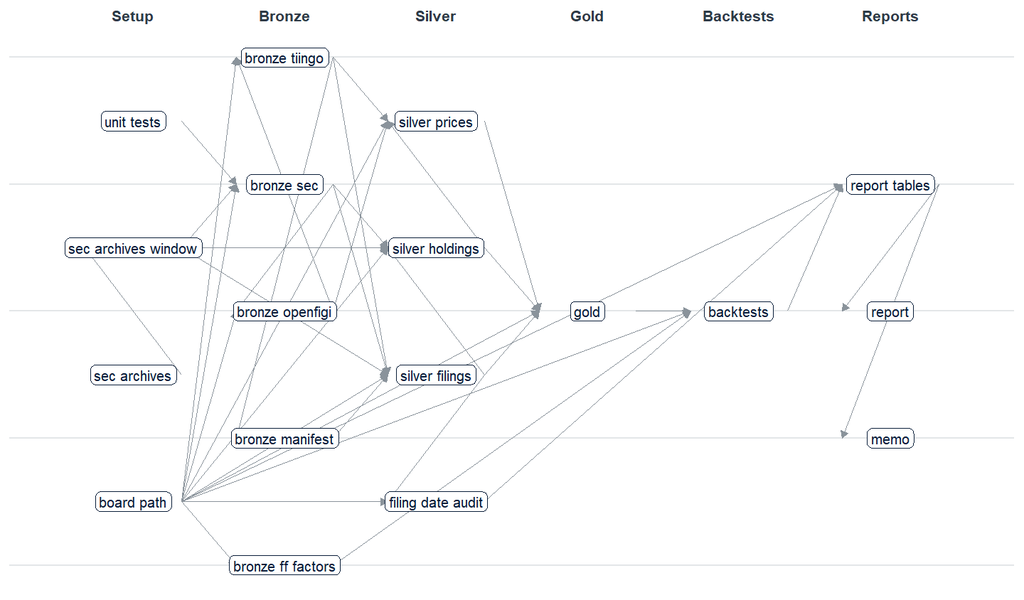

Targets of the pipeline, by layer. Each arrow is a dependency: a target reruns when anything upstream changes.

The pipeline is a `targets` graph, run with `targets::tar_make()`; targets reruns only what changed. The first target runs the unit tests, and the SEC, OpenFIGI and Tiingo downloads and every later layer depend on it, so none of them runs while a test fails. Two small steps do not wait for the tests: the listing of SEC archives and the Fama-French factor download. A new SEC batch is added by setting `window_end` in `_targets.R`; bronze records the window it covered, and the Tiingo cache must be refreshed because adjusted prices change after every split and dividend.

**Pins and duckdb.** Every table is a versioned pin on a local board. Its metadata records the versions of the pins it was built from and the counts its checks measured, so every number in this report can be traced to its inputs (Appendix A). The large tables (82,733,424 holdings state rows, 27,576,106 daily prices) are written as parquet and processed in `duckdb` with a memory limit and spill to disk; only aggregates are loaded into R.

## 2.7 The backtest engine: factoRverse

The backtests run on factoRverse, the author’s open-source R package for factor research and portfolio construction. It covers characteristic-sorted portfolio backtests, signal selection with multiple-testing control, machine-learning signal blending, and risk-based portfolio construction (equal weight, signal weight, cap-scaled, risk parity, hierarchical risk parity, mean-variance) with liquidity, turnover and concentration constraints and a transaction cost model.

**Typed inputs.** factoRverse works on S4 classes whose validity rules fix the data layout. A `meta_dataframe` holds a panel with key columns `id`, `tickers` and `dates` (`id` equal to `tickers-dates`, rows sorted) and numeric data columns, plus metadata (name, type, `current_date`, workflow). A `meta_xts` holds a time series, such as daily returns. A `port_backtest_config` holds every portfolio choice. Gold writes its panels in exactly this layout and the backtest layer wraps them, so a malformed input fails at construction instead of producing a wrong portfolio.

**Workflow of `run_port_backtest()`.** For each date, the engine:

1. checks every input and configuration (`check_inputs_port_backtest`);
2. builds the stock universe and the expected-return score from the signal (`derive_stock_universe_m_d_ref`, which winsorizes and transforms the signal);
3. classifies eligibility: quantile range, liquidity floors and user rules (`classify_investment_universe`);
4. sets target weights by the chosen method (`set_portfolio_weights`), estimating a covariance matrix when the method needs one;
5. on a rebalancing date, computes trade orders and costs (`allocate_port`, `calculate_trade_orders`, `calculate_transaction_costs`);
6. records portfolio metrics and statistics and rolls the weights forward with realised returns until the next rebalance (`roll_port`).

| Slot of port_backtest_results | Contents |
| --- | --- |
| port_backtest_config | The configuration that produced the backtest |
| port_weights_m_df | End-of-period weight of every stock at every date |
| transactions_log | Every trade: order, relative size, direct and market impact cost |
| port_returns_m_xts | Monthly raw and net returns |
| port_costs_m_xts | Direct cost, market impact, total cost and turnover |
| port_metrics_m_xts | Weighted portfolio metrics (here the signal and the liquidity percentile) |
| stock_universe_m_df | The universe with scores and eligibility flags at every date |
| port_stats_m_df | Portfolio statistics through time |
| final_stock_port | The latest portfolio |
| port_backtest_workflow | Object names, dates and parameters of each run |
| backtest_identifier | A unique name used to bundle backtests |

Backtests are bundled with `create_port_backtest_cohort()`. A `port_backtest_cohort` aligns the returns, costs and metrics of all its backtests. Every cohort of this study is pinned whole, so a reader can inspect it with factoRverse’s own methods:

```r
devtools::load_all()   # the package runs in place, it is not installed
board <- init_pipeline_board("data/prod")
cohort <- pins::pin_read(board, "backtests_cohort_f1_breadth_change_cs_unconditional")
q5 <- cohort@port_backtest_results_list[[5]]   # the top F1 quintile

summary(q5, summary_id = "Transactions Log")    # every trade and its cost
plot(q5, plot_id = "Time-Series of Port Returns")
plot(cohort, plot_id = "Time-Series of Raw Returns")        # the five quintiles
plot(cohort, plot_id = "Time-Series of Port Metrics")       # weighted F1 and liquidity
```

The top quintile’s transactions log holds one table per rebalance, 155,745 rows in all, one per stock and rebalance. Its first rows:

| tickers | dates | bop_port_weights | eop_port_weights | delta | order | direct_cost | market_impact_cost |
| --- | --- | --- | --- | --- | --- | --- | --- |
| BBG000B9X8C0 | 2014-03-01 | 0 | 0.00000 | 0.00000 | 0.000 | 0.00000 | 0 |
| BBG000B9XG87 | 2014-03-01 | 0 | 0.00000 | 0.00000 | 0.000 | 0.00000 | 0 |
| BBG000B9XRY4 | 2014-03-01 | 0 | 0.01974 | 0.01974 | 19737.221 | 0.00099 | 0 |
| BBG000B9YJ35 | 2014-03-01 | 0 | 0.00000 | 0.00000 | 0.000 | 0.00000 | 0 |
| BBG000B9ZXB4 | 2014-03-01 | 0 | 0.00000 | 0.00000 | 0.000 | 0.00000 | 0 |
| BBG000BB03M1 | 2014-03-01 | 0 | 0.00298 | 0.00298 | 2979.185 | 0.00015 | 0 |

# 3 Software engineering

**Roles.** The author designed the research question, the architecture (medallion layers, pins, `targets`, the factoRverse integration) and the workflow, made every methodological decision, and implemented parts of the code. Claude Code wrote most of the remaining code and tests under that direction; Codex reviewed each pull request independently. Every merge was the author’s decision.

**Test-driven development.** Functions are small, one per file, and written with their tests. The unit suite has over 300 tests. Fixtures are real data samples rather than invented rows: `toy_bronze_sec.rds` holds 32 real filers with forced edge cases (amendment chains, late reports), and `toy_silver_gold.rds` holds 22 real instruments and 400 filers over three formations, on which the gold SQL, the `dplyr` recomputations and the factoRverse backtests all run. Each data-quality suite also has tests that break its input on purpose and expect it to fail.

**Style and lint.** Code follows the tidyverse style, is formatted with `styler` and checked with `lintr` (100-character lines, snake case, explicit namespaces), and must be lint-free before any commit.

**Continuous integration.** GitHub Actions runs `R CMD check` and the unit suite on a clean Ubuntu machine on every pull request and every push to main, installing factoRverse from the copy in `vendor/`. No keys or data are needed.

**Reproducibility.** `renv.lock` fixes every package version, factoRverse included; a fresh clone restores with `renv::restore()`. `targets` records what was built from what, and pins record lineage and check results.

**Logging.** Each data-quality suite runs through `run_logged_test()`, which writes a timestamped log under `logs/tests/` and returns pass or fail; on failure the step stops before pinning. Long functions report progress when `verbose = TRUE`; pin metadata stores the counts each check measured; `targets` keeps timing and errors per target. API keys are read from the user environment and never printed or logged.

**Git workflow and review.** Every change goes through a feature branch, small commits with conventional messages, and a pull request. Each review finding is classified (accepted, accepted with modification, rejected) and fixed in its own commit. Examples of findings fixed this way: an overlap rule that read links from superseded filings, and a monotonicity test with the wrong null hypothesis.

**Backtest implementation.** `run_quantile_ladder()` runs each quintile of a signal as a factoRverse backtest and bundles the five into a cohort. A signal is one column of the gold signals panel, so F1b, F1c or a blend need a new column and no new backtest code.

- *Legs.* The long leg is the top quintile and the short leg the bottom quintile. Each leg’s weights sum to one at every rebalance, so the position is dollar neutral (one dollar long and one dollar short). The spread is the difference of the two legs’ monthly returns, which implicitly resizes the legs to equal value every month (the usual convention for academic factor spreads); weights within each leg drift between rebalances. In practice a desk rebalances to neutrality on a schedule and often targets equal beta instead; here the two legs have almost the same market beta (1.15 for the top quintile and 1.16 for the bottom one under cs), so dollar neutral is close to beta neutral.
- *Weights.* cs weights are the signal score times a liquidity score; the short leg is scored on the negated signal, so its largest weights go to the most negative F1.
- *Costs.* factoRverse charges two costs on every trade: a direct cost (fee times the dollar value traded) and a market impact cost that grows with the order’s size relative to the stock’s daily dollar volume, scaled by the stock’s volatility (a square-root impact model when its exponent is 0.5). The pre-registered scenarios use flat fees of 10, 25 and 50 bps per dollar traded, so impact is switched off here; an impact study by strategy size is an extension. The borrow fee is charged on the short leg.
- *Terminal events.* A stock whose price stops earns zero from then on (the position is closed at the last price); the terminal-stress scenario charges -30% in the month of the last price.

**Testing the backtest output.** The backtest checks require that net returns equal raw returns minus costs in every month, that trading happens only at rebalancing dates, that every portfolio holds at least 20 stocks, that every quantile covers the same months, and that net spreads fall as the fee rises. Each portfolio also carries two weighted metrics: the average signal, which must rise from the first to the fifth quintile, and the average liquidity percentile, which measures each leg’s size tilt.

# 4 Rationale

## 4.1 Literature

| Paper | Measure | Finding |
| --- | --- | --- |
| Chen, Hong and Stein (2002), JFE 66 | Change in breadth of mutual fund ownership | Stocks in the lowest decile of breadth change underperform the top decile by 6.38% over the next 12 months (1979 to 1998) |
| Nagel (2005), JFE 78 | Breadth and residual institutional ownership | After 1998, stocks with falling breadth outperformed those with rising breadth by a large margin, almost eliminating the effect over 1980 to 2003 |
| Sias, Starks and Titman (2006), Journal of Business 79 | Change in the number of institutions vs change in the fraction of shares held | Same-quarter returns relate more to changes in the number of institutions than to changes in shares held, suggesting that information plays a central role |
| Jegadeesh and Titman (1993), JF 48 | Past 3 to 12 month returns (momentum) | Buying past winners and selling past losers earns significant returns over 3 to 12 months, not explained by systematic risk or delayed reactions to common factors |
| Amihud (2002), Journal of Financial Markets 5 | Illiquidity: average of absolute return over dollar volume | Over time, expected market illiquidity raises expected stock excess returns, complementing the cross-sectional relation between illiquidity and returns |

Chen, Hong and Stein define breadth as the share of mutual funds holding a stock. Its change is computed over funds present in both quarters: holders at t minus holders at t-1, divided by all funds at t-1 (p. 180). Breadth rises steeply with firm size, from 0.25% of funds for the smallest size quintile to 7.09% for the largest (summary statistics, p. 182), and the change in breadth has very little persistence.

## 4.2 Mechanisms

F1 is meant to expose the portfolio to three channels.

- **Gradual trends.** If institutions build positions in a stock gradually as information spreads, a rise in breadth marks a trend that prices have not finished incorporating. This is the underreaction reading of momentum: Jegadeesh and Titman find that momentum profits are not due to delayed reactions to common factors, and returns around the earnings announcements of past winners and losers follow the same pattern. If F1 works through this channel, it should be related to momentum but may add to it.
- **Informed trading.** Sias, Starks and Titman find that returns move more with the number of institutions trading a stock than with the shares they trade, which they read as evidence that institutional trading carries information. Following entries by many institutions replicates part of that positioning.
- **Short-sale constraints.** In Chen, Hong and Stein’s model, when pessimistic investors cannot short, low breadth signals that they have left the stock, which is then overpriced. This channel is weaker here, because many 13F filers can short.

The 45-day disclosure lag works against all three: by the time a filing is public, part of the information may be in prices.

## 4.3 F1, F1b and F1c

F1 follows the paper. At each formation it counts the cohort filers holding a stock in quarters q-1 and q and divides the change by the cohort size. The only difference is the denominator: the paper divides by all funds at q-1 and this study by the filers present in both quarters. Either way the denominator is the same for every stock in a formation, so the rankings are identical, and F1 ranks stocks by the change in their holder count. Its extremes are therefore widely held stocks: a small company cannot gain 800 holders in a quarter. Two extensions measure the same idea without that size effect, each as a separate trial: F1b, the change in ownership measured by value, and F1c, the net number of new holders divided by the stock’s own holders at q-1.

## 4.4 Evaluation framework

The hypotheses, definitions and decision rules were written before any return was computed, in `docs/factor_memo_draft.md` (hypothesis in its Section 3, decision rules in Section 8), and every later change is dated in that document’s Deviations section. The evaluation uses:

- **FF6 alpha.** The monthly spread is regressed on the Fama-French five factors and momentum (UMD), with Newey and West (1987) standard errors at lags 3 and 6. UMD is included because institutions trade with past returns, so F1 could be momentum in disguise.
- **Conditioning on momentum.** A dependent double sort: stocks are split into momentum terciles and F1 quintiles are formed within each tercile, which asks whether F1 predicts returns among stocks with similar momentum.
- **Rank information coefficient.** At each formation, the rank correlation between F1 and each stock’s next three-month return, averaged over the 50 formations.
- **Monotonicity.** Returns should rise across all five quintiles, not only at the extremes. The test requires every adjacent spread to be positive (intersection-union), in the spirit of Patton and Timmermann (2010); it is a diagnostic.
- **Weighting robustness.** A credible signal must work under cs, equal weights and risk parity, and not only through small, illiquid stocks. A scheme is never selected.
- **Multiple testing.** Once F1b and F1c are tested, the false discovery rate is controlled with Benjamini and Hochberg (1995) across the three signals, and the Sharpe ratio is deflated for the number of trials (Bailey and Lopez de Prado 2014).
- **Costs.** Net results at fees of 10, 25 and 50 bps and the break-even fee.
- **Benchmarks.** The long-short spread is a zero-investment portfolio, so it is judged against zero and against the factors. The long legs are compared with SPY, the market a US equity investor holds by default, and with an equal-weight portfolio of the whole universe, which shows what any portfolio drawn from the same 1,000 stocks earned.

# 5 Results

## 5.1 Dataset

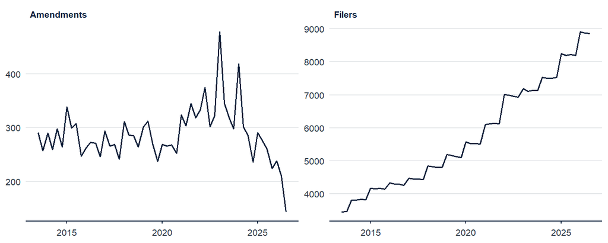

Filers per report quarter (one original report each) and amendments.

Almost every filer files exactly one original report per quarter, so the number of filers is also the number of reports. It grows from 3,453 in 2013 to 8,908. In total the pipeline holds 322,955 filings and 82,733,424 holdings state rows.

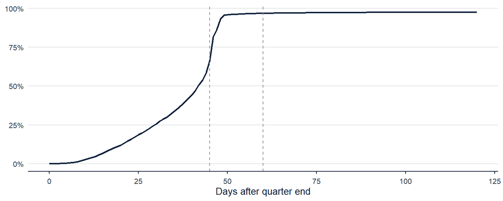

Share of original reports usable by days after quarter end (2014 to 2026).

Filers tend to file close to the deadline: 25.7% of reports are usable within 30 days of quarter end, 44.4% within 40 and 66.3% within 45. The jump to 81.4% at 46 days and 95.9% at 50 days comes from reports filed on the deadline itself: a report filed on day 45 becomes usable the next trading day, later still when the deadline falls on a weekend. By day 60, close to the formation dates, 96.7% are usable. The remaining 2.5% arrive after four months; they enter at the first formation after their own usable date.

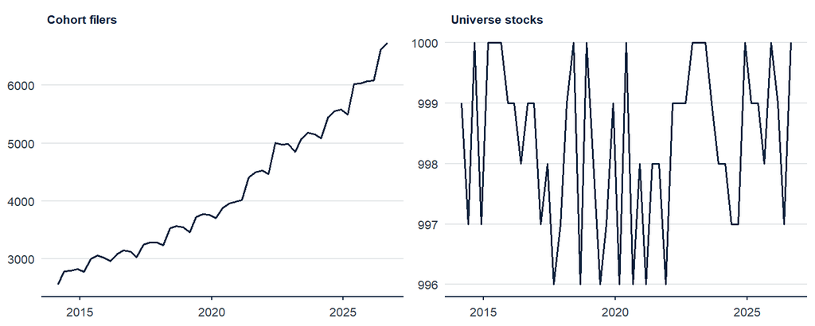

Cohort filers and universe stocks per formation.

The cohort holds about 3,800 filers per formation. The universe is close to 1,000 stocks at every formation by construction; it falls slightly below when a few top-ranked stocks have no holder in one of the two quarters.

| Outcome | Meaning | Candidate rows | Share |
| --- | --- | --- | --- |
| no_price_source | No Tiingo price series for the CUSIP’s ticker | 16092 | 0.056 |
| identity_unverifiable | No quarter-q cohort holder, so the mapping cannot be checked | 15055 | 0.053 |
| identity_rejected | Most holders’ value per share disagrees with Tiingo’s close | 45365 | 0.159 |
| cusip_change_suspect | At least 20 holders, more than half new: likely a CUSIP change | 4985 | 0.017 |
| not_traded_at_t | No price on the formation day | 2169 | 0.008 |
| price_below_min | Previous close below USD 5 | 39134 | 0.137 |
| low_presence | Traded on less than 90% of the previous 63 days | 14937 | 0.052 |
| short_history | Less than a year of price history | 7028 | 0.025 |
| below_liquidity_rank | Passed every screen but outside the 1,000 most liquid | 89702 | 0.314 |
| zero_holders | No cohort holder in q-1 or q | 84 | 0.000 |
| member | Universe member | 50916 | 0.178 |

Each row of the table counts candidate stock-formations by the first screen they failed, in the order the screens are applied. Candidates are all stocks held by the cohort, about 5,500 per formation, most of them small. The liquidity rank removes the largest group, after the price floor and the identity checks. Almost all stocks removed by the identity checks are small stocks held by few filers, so their effect on the liquid universe is limited.

## 5.2 Quintile ladders

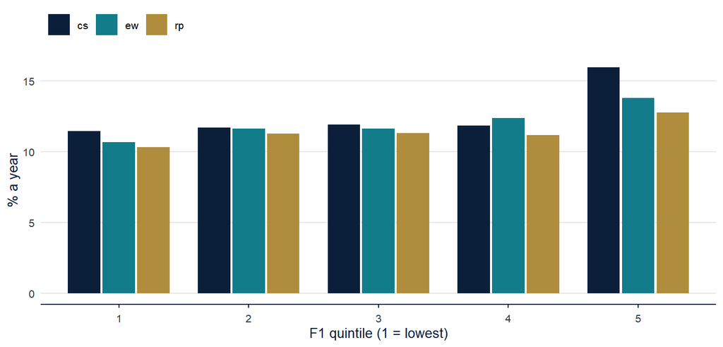

Annual return of each F1 quintile by weighting scheme.

| Weights | Quintile | Return, % a year | Volatility, % | Liquidity percentile | Stocks |
| --- | --- | --- | --- | --- | --- |
| cs | 1 | 11.46 | 19.32 | 0.73 | 208 |
| cs | 2 | 11.71 | 18.03 | 0.56 | 218 |
| cs | 3 | 11.92 | 17.32 | 0.55 | 221 |
| cs | 4 | 11.84 | 17.26 | 0.61 | 216 |
| cs | 5 | 15.94 | 19.72 | 0.82 | 206 |
| ew | 1 | 10.67 | 19.72 | 0.55 | 208 |
| ew | 2 | 11.64 | 18.87 | 0.43 | 218 |
| ew | 3 | 11.64 | 17.74 | 0.42 | 221 |
| ew | 4 | 12.39 | 17.71 | 0.47 | 216 |
| ew | 5 | 13.78 | 18.16 | 0.64 | 206 |
| rp | 1 | 10.31 | 16.44 | 0.57 | 208 |
| rp | 2 | 11.28 | 15.95 | 0.45 | 218 |
| rp | 3 | 11.30 | 15.43 | 0.44 | 221 |
| rp | 4 | 11.16 | 15.41 | 0.49 | 216 |
| rp | 5 | 12.77 | 15.27 | 0.65 | 206 |

Returns are flat from the first to the fourth quintile and rise at the fifth. The monotonicity test does not reject a flat relation (p = 0.53 under cs, 0.50 under equal weights and 0.57 under risk parity), so whatever premium exists sits in the top quintile.

The liquidity percentile (the weighted average percentile of 63-day dollar volume, 1 = most liquid) shows the size tilt. Even with equal weights, both extreme quintiles hold more liquid stocks (0.55 and 0.64) than the middle ones (0.42 to 0.47), because the extremes of F1 are widely held stocks. cs weights raise both legs further (0.73 and 0.82). The largest F1 values at the last formation were large technology stocks gaining hundreds of holders:

| Side | Ticker | F1 | Holders q-1 | Holders q |
| --- | --- | --- | --- | --- |
| top | INTC | 0.1282 | 1797 | 2660 |
| top | MU | 0.1121 | 2252 | 3007 |
| top | AMD | 0.1051 | 2356 | 3064 |
| top | SNDK | 0.0787 | 824 | 1354 |
| top | MRVL | 0.0786 | 1064 | 1593 |
| top | AMAT | 0.0708 | 2135 | 2612 |
| top | LRCX | 0.0636 | 1900 | 2328 |
| top | STX | 0.0625 | 994 | 1415 |
| top | DELL | 0.0612 | 1122 | 1534 |
| top | PANW | 0.0561 | 1746 | 2124 |
| bottom | T | -0.0389 | 2141 | 1879 |
| bottom | NFLX | -0.0321 | 2735 | 2519 |
| bottom | ACN | -0.0310 | 1467 | 1258 |
| bottom | INTU | -0.0309 | 1390 | 1182 |
| bottom | BSX | -0.0252 | 1144 | 974 |
| bottom | ADBE | -0.0245 | 1508 | 1343 |
| bottom | CRM | -0.0236 | 1891 | 1732 |
| bottom | CVX | -0.0218 | 3299 | 3152 |
| bottom | NKE | -0.0203 | 1259 | 1122 |
| bottom | CMCSA | -0.0200 | 1359 | 1224 |

## 5.3 Spreads and alpha

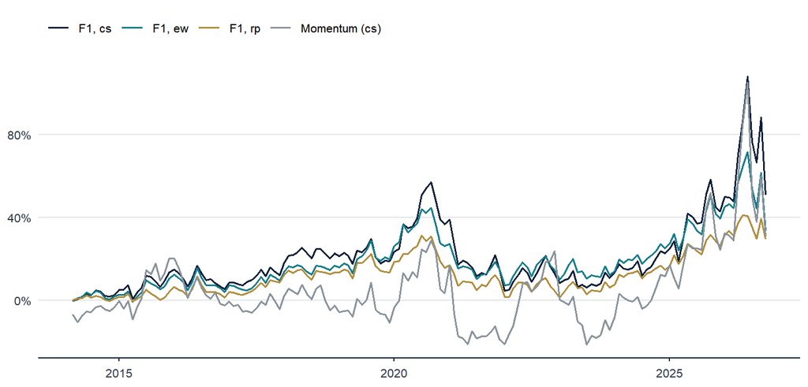

Cumulative gross spread (top minus bottom quintile).

All three F1 spreads end positive, with long flat stretches and a strong final two years. No FF6 alpha is significant (summary table): the t-statistics are 1.06 (cs), 0.94 (equal weights) and 0.41 (risk parity). The terminal-stress scenario raises the spread to 4.88% a year, because stocks that stop trading are more often in the bottom quintile.

| Portfolio (gross, long only) | Mean, % a year | 95% interval of the mean |
| --- | --- | --- |
| SPY | 13.85 | [7.45, 20.25] |
| Equal-weight universe | 12.23 | [3.88, 20.58] |
| Top F1 quintile, cs | 15.94 | [6.59, 25.30] |
| Bottom F1 quintile, cs | 11.46 | [2.16, 20.76] |

Over the same months SPY earned 13.85% a year and an equal-weight portfolio of the universe 12.23%. The top F1 quintile earned more than both before costs and the bottom quintile less than both, but the intervals of all four overlap widely.

## 5.4 Year by year

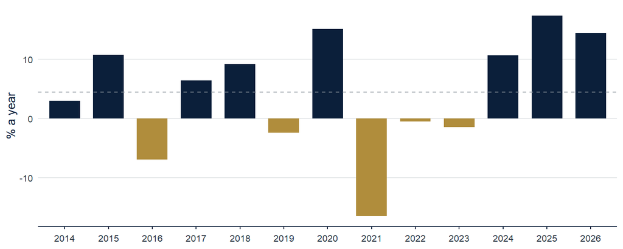

Gross cs spread by calendar year (bars) and the full-sample mean (line). 2014 starts in March and 2026 ends in October.

The spread is far from steady: it ranges from -16.5% in 2021 to 17.4% in 2025, and 5 of the 13 years are negative. No single year carries the result, though: leaving any one year out moves the mean between 3.37% (without 2025) and 6.28% (without 2021), against 4.48% for the whole sample. The last three years, all strongly positive, contribute a large part of it.

## 5.5 Costs and turnover

| Weights | Fee, bps per dollar traded | Gross spread | Trading cost | Net spread |
| --- | --- | --- | --- | --- |
| cs | 0 | 4.48 | 0.00 | 4.48 |
| cs | 10 | 4.48 | 1.11 | 3.37 |
| cs | 25 | 4.48 | 2.77 | 1.71 |
| cs | 50 | 4.48 | 5.55 | -1.06 |
| ew | 0 | 3.10 | 0.00 | 3.10 |
| ew | 10 | 3.10 | 1.19 | 1.91 |
| ew | 25 | 3.10 | 2.98 | 0.13 |
| ew | 50 | 3.10 | 5.95 | -2.85 |
| rp | 0 | 2.46 | 0.00 | 2.46 |
| rp | 10 | 2.46 | 1.22 | 1.23 |
| rp | 25 | 2.46 | 3.05 | -0.60 |
| rp | 50 | 2.46 | 6.11 | -3.65 |

All values are percent a year. The trading cost scales with the fee, so the net spread falls by the same amount for every 10 bps: from 4.48% gross to 1.71% at 25 bps under cs, and below zero at 50 bps under every scheme. A borrow fee of 100 bps a year on the short leg lowers each net spread by a further 1 percentage point. The fee at which the cs spread earns nothing is 40 bps per dollar traded.

The cause is turnover. Under cs weights the bottom leg trades 1.47 times its value at each rebalance and the top leg 1.30 times, counting purchases and sales: a leg that sells 65 cents and buys 65 cents per dollar it holds trades 1.3 times its value. With four rebalances a year and two legs, a 25 bps fee then costs close to 3% a year. Turnover depends on the weighting scheme and on how far weights drift between rebalances, but mostly on the signal: F1’s rank correlation between consecutive formations averages 0.11, so rankings change a lot from one quarter to the next. A signal averaged over two quarters may keep more of each quintile and trade less; that is a hypothesis for the cost extension, not a result.

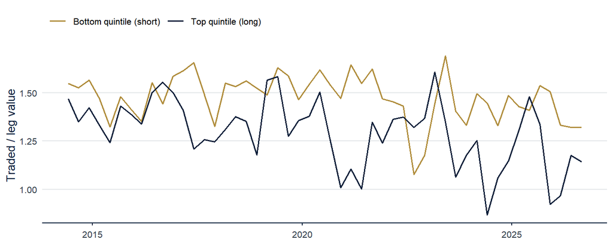

Value traded per rebalance by each leg under cs weights, as a multiple of the leg’s value.

Turnover is high at every rebalance rather than in a few episodes: the legs trade between 0.87 and 1.69 times their value and drift down only slightly over the sample, so the cost estimate does not depend on a particular period.

## 5.6 Conditional on momentum

| Momentum tercile | F1 spread, % a year | Volatility, % | Sharpe | FF6 alpha | t |
| --- | --- | --- | --- | --- | --- |
| Low momentum | 1.84 | 10.97 | 0.17 | 1.47 | 0.64 |
| Middle | 2.41 | 9.52 | 0.25 | 2.11 | 0.91 |
| High momentum | 5.93 | 14.83 | 0.40 | 3.57 | 1.25 |
| Average of the three | 3.39 | 9.13 | 0.37 | 2.38 | 1.44 |
| Momentum spread (reference) | 5.22 | 24.73 | 0.21 | 1.19 | 0.39 |

The table repeats the F1 sort inside each momentum tercile: within stocks with similar past returns, it compares those with the largest and smallest breadth change. F1 earns a positive spread in all three terciles and the spread grows with momentum, from 1.84% a year among past losers to 5.93% among past winners, where it reaches a Sharpe ratio of 0.40 and an FF6 alpha of 3.57% a year. Averaged over the terciles it has a Sharpe ratio of 0.37, above both the unconditional F1 spread (0.29) and the momentum spread (0.21), and the alpha closest to significance of all the tests. Rising breadth among stocks that have already risen is what the gradual-trend reading of F1 predicts. Still, none of the three spreads is significant on its own, and the winners tercile is one of three, noticed after seeing results, so it is a hypothesis for a new pre-registered trial rather than a finding. Neither is the average significant (3.39% a year, alpha t = 1.44).

| Portfolio (gross spreads, cs) | Return, % a year | Volatility, % | Sharpe ratio |
| --- | --- | --- | --- |
| Momentum alone | 5.22 | 24.73 | 0.21 |
| F1 alone | 4.48 | 15.68 | 0.29 |
| 50% momentum + 50% F1 | 4.85 | 19.51 | 0.25 |

Does F1 improve a momentum portfolio? The unconditional spreads move together (their monthly returns have a correlation of 0.86), yet adding F1 helps a momentum investor: holding half of each gives a Sharpe ratio of 0.25 against 0.21 for momentum alone, because F1 earns most of momentum’s return with less volatility (15.7% against 24.7%). F1 alone has the higher Sharpe ratio still (0.29). This comparison is descriptive and gross of costs, not one of the pre-registered tests.

## 5.7 Momentum over the same period

| UMD | Months | Mean, % a year | Volatility | t | CAPM alpha | t |
| --- | --- | --- | --- | --- | --- | --- |
| study window | 151 | 2.66 | 13.96 | 0.76 | 6.00 | 2.05 |
| since 1963 | 759 | 7.25 | 14.58 | 3.98 | 8.36 | 4.96 |

Over the study window UMD averaged 2.66% a year with t = 0.76, against 7.25% (t = 3.98) since 1963, with large gains and losses from year to year. The study’s own momentum spread follows UMD closely and has an FF6 alpha near zero. Momentum is the most robust anomaly in this family, yet over the study window its average was not distinguishable from zero. An insignificant F1 alpha over the same period is therefore weak evidence either way.

# 6 Limitations

- **Power.** Before seeing any result, the pre-registration set 2% a year as the smallest alpha that would matter economically. With this sample, a true FF6 alpha would have to be about 6.0% a year, and a true mean spread about 10.8%, to be detected with 80% probability, so effects of economic interest could be present and undetected. Four times the history would halve these thresholds.
- **Size tilt.** F1’s extremes are widely held stocks and cs weights add liquidity. F1c removes the structural part.
- **Sample period.** The whole sample lies after the breadth reversal reported by Nagel (2005).
- **Identity mapping.** OpenFIGI and Tiingo reflect today’s mappings: 3.7% of 13F value is common stock with no Tiingo price series and 0.45% is removed by the identity checks, mostly dead firms.
- **Confidential treatment.** Withheld positions look like exits until revealed.
- **Signal freshness.** Signals are formed at month end, up to two weeks after most filings are public.
- **Stocks that go stale after formation** earn zero until the next formation and do not receive the stress return.

# 7 Extensions

1. F1b and F1c, each a separate trial, with false discovery rate control across F1, F1b and F1c and a deflated Sharpe ratio over all trials.
2. F1 among past winners, the strongest pattern in the results, pre-registered as a conditional strategy and counted as a new trial.
3. Costs: turnover by leg and through time, factoRverse’s market impact model by strategy size, realistic fees and borrow, and F1 smoothed over two quarters.
4. Sector checks of the top-quintile premium (the leave-one-year-out check is in Section 5.4).
5. Disclosure-lag profile: returns in months 1 to 12 after formation.
6. Activity-based filer split and a capacity-based universe.
7. Continuous integration on macOS and Windows (coverage and lint already run on Ubuntu).

## 8 Appendix A: pin lineage

| Pin | Version | Created | Inputs |
| --- | --- | --- | --- |
| backtests_benchmark | 20261108T151623Z-ddaea | 2026-11-08 12:16:23 | 7 |
| backtests_cohort_f1_breadth_change_cs_terminal_stress | 20261108T212019Z-0c757 | 2026-11-08 18:20:19 | 3 |
| backtests_cohort_f1_breadth_change_cs_unconditional | 20261108T211909Z-4ba27 | 2026-11-08 18:19:09 | 3 |
| backtests_cohort_f1_breadth_change_ew_unconditional | 20261108T211920Z-6b95e | 2026-11-08 18:19:20 | 3 |
| backtests_cohort_f1_breadth_change_in_mom_12_1_cs_tercile_1 | 20261108T211950Z-4c002 | 2026-11-08 18:19:50 | 3 |
| backtests_cohort_f1_breadth_change_in_mom_12_1_cs_tercile_2 | 20261108T212001Z-3f221 | 2026-11-08 18:20:01 | 3 |
| backtests_cohort_f1_breadth_change_in_mom_12_1_cs_tercile_3 | 20261108T212010Z-64992 | 2026-11-08 18:20:10 | 3 |
| backtests_cohort_f1_breadth_change_rp_unconditional | 20261108T211929Z-d761d | 2026-11-08 18:19:29 | 3 |
| backtests_cohort_mom_12_1_cs_reference | 20261108T212034Z-016df | 2026-11-08 18:20:34 | 3 |
| backtests_inference | 20261108T190425Z-44a9f | 2026-11-08 16:04:25 | 7 |
| backtests_ladder_returns | 20261108T190424Z-5f5a4 | 2026-11-08 16:04:24 | 7 |
| backtests_monotonicity | 20261108T171634Z-aa15a | 2026-11-08 14:16:34 | 7 |
| backtests_rank_ic | 20261108T151624Z-67bca | 2026-11-08 12:16:24 | 7 |
| backtests_rank_ic_by_formation | 20261108T151624Z-77488 | 2026-11-08 12:16:24 | 7 |
| backtests_spreads | 20261108T190424Z-ae01d | 2026-11-08 16:04:24 | 7 |
| backtests_summary | 20261108T190425Z-65a45 | 2026-11-08 16:04:25 | 7 |
| bronze_ff_factors_m | 20261108T142741Z-b955e | 2026-11-08 11:27:41 | 0 |
| bronze_openfigi | 20261107T121832Z-23985 | 2026-11-07 09:18:32 | 54 |
| bronze_tiingo_prices | 20261107T153640Z-f2b6a | 2026-11-07 12:36:40 | 1 |
| gold_benchmark_d | 20261108T011041Z-dfde3 | 2026-11-07 22:10:41 | 10 |
| gold_benchmark_m | 20261108T011041Z-73ae2 | 2026-11-07 22:10:41 | 10 |
| gold_cohort | 20261108T113727Z-8c78f | 2026-11-08 08:37:27 | 10 |
| gold_daily_returns_d | 20261108T113727Z-b640f | 2026-11-08 08:37:27 | 10 |
| gold_fwd_1m_returns_m_df | 20261108T133658Z-871b7 | 2026-11-08 10:36:58 | 10 |
| gold_liquidity_m_df | 20261108T133658Z-c00da | 2026-11-08 10:36:58 | 10 |
| gold_signals_m_df | 20261108T133658Z-2cc61 | 2026-11-08 10:36:58 | 10 |
| gold_universe_diagnostics | 20261108T133659Z-26a4a | 2026-11-08 10:36:59 | 10 |
| gold_volatility_m_df | 20261108T133658Z-67146 | 2026-11-08 10:36:58 | 10 |
| silver_filing_date_audit | 20261108T205802Z-7dede | 2026-11-08 17:58:02 | 1 |
| silver_filing_relations | 20261107T172515Z-508fb | 2026-11-07 14:25:15 | 55 |
| silver_filings | 20261107T172515Z-49aa9 | 2026-11-07 14:25:15 | 55 |
| silver_holdings_state | 20261107T231320Z-9a0b2 | 2026-11-07 20:13:20 | 55 |
| silver_holdings_versions | 20261107T200502Z-107c0 | 2026-11-07 17:05:02 | 55 |
| silver_identity_checks | 20261107T231709Z-6a5cd | 2026-11-07 20:17:09 | 4 |
| silver_liquidity_d | 20261107T231708Z-289be | 2026-11-07 20:17:08 | 4 |
| silver_prices_d | 20261107T231654Z-76544 | 2026-11-07 20:16:54 | 4 |
| silver_returns_d | 20261107T231656Z-7284f | 2026-11-07 20:16:56 | 4 |
| silver_security_master | 20261107T231650Z-a5572 | 2026-11-07 20:16:50 | 4 |
| silver_terminal_events | 20261107T231709Z-02073 | 2026-11-07 20:17:09 | 4 |
| silver_trading_calendar | 20261107T164008Z-66d0d | 2026-11-07 13:40:08 | 1 |

## 9 Appendix B: data-quality counts

| Pin | Count | Value |
| --- | --- | --- |
| bronze_tiingo_prices | n_rows | 27,999,426 |
| bronze_tiingo_prices | n_bad_adj_rows | 9,680 |
| bronze_openfigi | n_rows | 79,490 |
| bronze_openfigi | n_malformed_cusips | 20,293 |
| silver_filings | n_rows | 322,955 |
| silver_holdings_state | n_state_rows | 82,733,424 |
| silver_holdings_state | n_untyped_amendments_ignored | 53 |
| silver_holdings_state | n_malformed_cusips | 31,451 |
| silver_holdings_state | n_filings_with_rows_not_in_silver | 11 |
| silver_security_master | n_rows | 17,598 |
| silver_security_master | n_ambiguous_cusips | 176 |
| silver_prices_d | n_rows | 27,576,106 |
| silver_identity_checks | n_rows | 243,240 |
| silver_identity_checks | n_identity_suspects | 1,588 |
| silver_identity_checks | share_rows_thousand | 0.0109 |
| silver_identity_checks | share_rows_thousandth | 0.0386 |